# BMS353 Week 4

November 2020

## Week 3 recap

- first glimpse of our RNA-seq dataset
- used QA tools to un-cover sample swaps and annotation issues

## Week 4 overview

- different sources of variation affecting counts
- use `DESeq2` to assess differential expression between groups of interest

## Data Transformation

- we obtain raw counts for each gene, but these are relative counts
- the relationship between counts and RNA-expression is not the same for all genes across all samples
  - there are a finite number of counts available for each sample, and how they are distributed among the genes may vary from sample to sample

## Depth

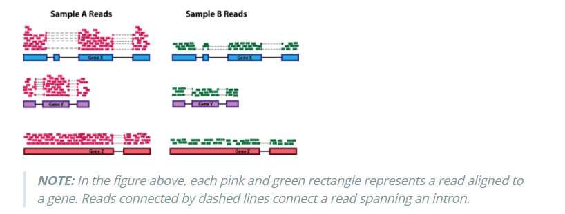

Differing sequencing depth (image from Harvard Chan Bioinformatics Core)

## Gene Length

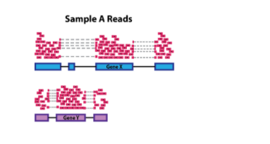

Longer genes likely to be sequenced more (image from Harvard Chan Bioinformatics Core)

## Library composition

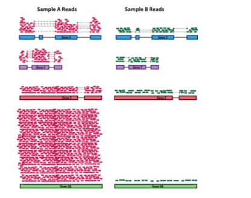

Highly-expressed genes over-represented at the cost of lowly expressed genes (image from Harvard Chan Bioinformatics Core)

## Statistical testing

- the count for a given gene is influenced by many technical factors
- overall goal is to see assess whether a gene varies more between groups (biological variation) than it does within a group (technical or uninteresting variation)
- for microarrays we used a t-test as our basis - as we could assume a *normal* distribution

## Statistical testing

- using a t-test as we did for microarrays would not be appropriate
- instead we use something called the *negative-binomial*
- this means we have to estimate the *dispersion* for each gene
- the output is the same; a test statistic and a p-value

## “Median Ratio” Normalisation

- create a “reference” sample that comprises the average counts for each gene
- for a given sample, divide each gene by the average counts
  - then for each sample take the median of these values
  - this is the *scale-factor*
- doesn’t account for gene-length - but this isn’t required when comparing the same gene across all samples

## The DESeq pipeline

- DESeq2 provides a one-step method to carry out the required normalised and apply statistical tests
  - `DESeq(dds)`
  - we can run the steps manually if we wish..
- notice that the *raw counts* are used (not the input to PCA)
- the comparisons performed are determined by the `design`

## Design specification

- R’s `~` notation is used to define the *design* of the experiment
- for simple cases `~condition` means compare conditions in our dataset
  - `condition` has to be a column in our *meta data*

```
## ~condition
```

```
## DataFrame with 12 rows and 1 column
##          condition
##           <factor>
## sample1          A
## sample2          A
## sample3          A
## sample4          A
## sample5          A
## ...            ...
## sample8          B
## sample9          B
## sample10         B
## sample11         B
## sample12         B
```

## Printing results

- results are in a familiar format; one row for each gene
- adjusted p-values are automatically calculated
- can use familiar `dplyr` functions to manipulate
  - `filter`, `arrange` etc
- pay attention to the contrast that is calculated and the *baseline*

```
## log2 fold change (MLE): condition B vs A
## Wald test p-value: condition B vs A
## DataFrame with 3 rows and 6 columns
##        baseMean log2FoldChange     lfcSE       stat    pvalue      padj
##       <numeric>      <numeric> <numeric>  <numeric> <numeric> <numeric>
## gene1   16.2406      1.0026648  0.558464  1.7953970 0.0725905  0.920711
## gene2   24.1451     -0.2374562  0.471056 -0.5040937 0.6141956  0.999836
## gene3   57.1263     -0.0185595  0.365659 -0.0507563 0.9595197  0.999836
```

## Column meanings

- `baseMean`; average count for the gene
- `log2FoldChange`; expression difference between sample groups on log\(_2\) scale. i.e. 1 = 2\(^1\) = 2, 1.5 = 2\(^{1.5}\)
- (`lfcSE`; variability of the log fold change estimate)
- (`stat`; the test statistic)
- `pvalue`; the p-value - probability of obtaining the observed log fold-change due to chance alone
- `padj`; the p-value after multiple testing adjustment (BH)

## Beyond the two-group analysis

- can apply differential expression to a subset of the data
- can adjust the model to account for batch effects and other confounding factors
  - `~ CellType + condition`
- can change baseline for the contrast, or compare different sample groups

## Further Viewing / Reading

- https://hbctraining.github.io/DGE_workshop/lessons/02_DGE_count_normalization.html
- [Differential expression analysis](https://youtu.be/5tGCBW3_0IA) - 26 minutes
- [RNA-seq count normalisation explained](https://youtu.be/TTUrtCY2k-w) - 10 minutes